# MD 10 Preview Season 2627

Tottenham vs Crystal Palace - 31-10-2026

|  | Possession Possession % | Possession On Ball Time | Possession Touches | Possession PKBox Touches | Possession Field Tilt % | Shots Total Shots | Shots OFF Shots | Shots ONT Shots | Shots 6yrd box Shots | Shots PK Box Shots | Shots Outside Box Shots | Shots Blocked Shots | Shots BCs | Shots Goals | Shots xG | Shots NPxG | Shots xGOT | Threat EPV | Threat EPV % xG Con. | Threat EPV % NPxG Con. | Passes Attempted Passes | Passes Successful Passes | Passes Pass Success % | Passes Long Passes | Passes Long Ball Rate | Passes Crosses | Passes Cross Success % | Passes Corners | Passes Short Corners | … |
| --- | --- | --- | --- | --- | --- | --- | --- | --- | --- | --- | --- | --- | --- | --- | --- | --- | --- | --- | --- | --- | --- | --- | --- | --- | --- | --- | --- | --- | --- | --- |
| 1st Quarter |  |  |  |  |  |  |  |  |  |  |  |  |  |  |  |  |  |  |  |  |  |  |  |  |  |  |  |  |  | … |
| Crystal Palace | 28.8% | 8.30 | 114 | 0 | 13.6% | 1 | 0 | 1 | 0 | 0 | 1 | 0 | 0 | 0 | 0.04 | 0.04 | 0.08 | 0.20 | 19.9% | 19.9% | 60 | 47 | 78.3% | 11 | 18.3% | 2 | 0.0% | 0 | 0 | … |
| Tottenham | 71.2% | 14.80 | 282 | 12 | 86.4% | 4 | 1 | 1 | 2 | 4 | 0 | 2 | 1 | 1 | 0.40 | 0.40 | 0.21 | 0.87 | 45.8% | 45.8% | 215 | 201 | 93.5% | 3 | 1.4% | 9 | 22.2% | 3 | 1 | … |
| 2nd Quarter |  |  |  |  |  |  |  |  |  |  |  |  |  |  |  |  |  |  |  |  |  |  |  |  |  |  |  |  |  | … |
| Crystal Palace | 30.1% | 6.30 | 104 | 0 | 1.4% | 0 | 0 | 0 | 0 | 0 | 0 | 0 | 0 | 0 | 0.00 | 0.00 | 0.00 | 0.12 | 0.0% | 0.0% | 63 | 47 | 74.6% | 11 | 17.5% | 0 | 0.0% | 0 | 0 | … |
| Tottenham | 69.9% | 10.70 | 242 | 13 | 98.6% | 4 | 2 | 1 | 0 | 2 | 2 | 1 | 0 | 0 | 0.26 | 0.26 | 0.03 | 1.12 | 23.2% | 23.2% | 194 | 184 | 94.8% | 4 | 2.1% | 10 | 20.0% | 3 | 1 | … |
| 3rd Quarter |  |  |  |  |  |  |  |  |  |  |  |  |  |  |  |  |  |  |  |  |  |  |  |  |  |  |  |  |  | … |
| Crystal Palace | 28.5% | 5.70 | 117 | 2 | 5.1% | 1 | 0 | 0 | 0 | 1 | 0 | 1 | 0 | 0 | 0.11 | 0.11 | 0.00 | 0.18 | 60.1% | 60.1% | 55 | 31 | 56.4% | 15 | 27.3% | 0 | 0.0% | 0 | 0 | … |
| Tottenham | 71.5% | 16.00 | 294 | 24 | 94.9% | 17 | 6 | 3 | 2 | 10 | 7 | 8 | 1 | 0 | 1.12 | 1.12 | 0.50 | 1.66 | 67.3% | 67.3% | 221 | 203 | 91.9% | 5 | 2.3% | 11 | 36.4% | 5 | 3 | … |
| 4th Quarter |  |  |  |  |  |  |  |  |  |  |  |  |  |  |  |  |  |  |  |  |  |  |  |  |  |  |  |  |  | … |
| Crystal Palace | 27.2% | 4.70 | 91 | 0 | 0.8% | 0 | 0 | 0 | 0 | 0 | 0 | 0 | 0 | 0 | 0.00 | 0.00 | 0.00 | 0.07 | 0.0% | 0.0% | 45 | 26 | 57.8% | 11 | 24.4% | 0 | 0.0% | 0 | 0 | … |
| Tottenham | 72.8% | 10.90 | 244 | 19 | 99.2% | 9 | 3 | 4 | 4 | 8 | 1 | 2 | 4 | 1 | 1.75 | 1.75 | 2.36 | 1.63 | 107.6% | 107.6% | 185 | 171 | 92.4% | 3 | 1.6% | 9 | 22.2% | 8 | 5 | … |

X @Barts78 · Bluesky @barts78 · Mastodon @DrBarts · GitHub Barts78 · LinkedIn Phil-barter · Data: Opta

**Match Summary - By Game State**

Tottenham vs Crystal Palace - 31-10-2026

|  | Possession Possession % | Possession On Ball Time | Possession Touches | Possession PKBox Touches | Possession Field Tilt % | Shots Total Shots | Shots OFF Shots | Shots SoT | Shots 6yrd box Shots | Shots PK Box Shots | Shots Outside Box Shots | Shots Blocked Shots | Shots BCs | Shots Goals | Shots xG | Shots NPxG | Shots xGOT | Threat EPV | Threat EPV % xG Con. | Threat EPV % NPxG Con. | Passes Attempted Passes | Passes Successful Passes | Passes Pass Success % | Passes Long Passes | Passes Long Ball Rate | Passes Crosses | Passes Cross Success % | Passes Corners | Passes Short Corners | … |
| --- | --- | --- | --- | --- | --- | --- | --- | --- | --- | --- | --- | --- | --- | --- | --- | --- | --- | --- | --- | --- | --- | --- | --- | --- | --- | --- | --- | --- | --- | --- |
| Draw |  |  |  |  |  |  |  |  |  |  |  |  |  |  |  |  |  |  |  |  |  |  |  |  |  |  |  |  |  | … |
| Crystal Palace | 28.5% | 7.40 | 109 | 0 | 14.3% | 1 | 0 | 1 | 0 | 0 | 1 | 0 | 0 | 0 | 0.04 | 0.04 | 0.08 | 0.20 | 20.5% | 20.5% | 58 | 46 | 79.3% | 10 | 17.2% | 2 | 0.0% | 0 | 0 | … |
| Tottenham | 71.5% | 14.60 | 273 | 11 | 85.7% | 4 | 1 | 1 | 2 | 4 | 0 | 2 | 1 | 1 | 0.40 | 0.40 | 0.21 | 0.86 | 46.5% | 46.5% | 212 | 198 | 93.4% | 3 | 1.4% | 7 | 28.6% | 3 | 1 | … |
| Home Garbage Time |  |  |  |  |  |  |  |  |  |  |  |  |  |  |  |  |  |  |  |  |  |  |  |  |  |  |  |  |  | … |
| Crystal Palace | 26.2% | 3.00 | 81 | 0 | 0.8% | 0 | 0 | 0 | 0 | 0 | 0 | 0 | 0 | 0 | 0.00 | 0.00 | 0.00 | 0.07 | 0.0% | 0.0% | 42 | 25 | 59.5% | 9 | 21.4% | 0 | 0.0% | 0 | 0 | … |
| Tottenham | 73.8% | 10.30 | 228 | 15 | 99.2% | 6 | 3 | 2 | 2 | 5 | 1 | 1 | 2 | 0 | 1.09 | 1.09 | 0.94 | 1.34 | 81.1% | 81.1% | 176 | 163 | 92.6% | 2 | 1.1% | 7 | 14.3% | 7 | 5 | … |
| Home Lead |  |  |  |  |  |  |  |  |  |  |  |  |  |  |  |  |  |  |  |  |  |  |  |  |  |  |  |  |  | … |
| Crystal Palace | 29.6% | 14.60 | 236 | 2 | 3.3% | 1 | 0 | 0 | 0 | 1 | 0 | 1 | 0 | 0 | 0.11 | 0.11 | 0.00 | 0.31 | 35.7% | 35.7% | 123 | 80 | 65.0% | 29 | 23.6% | 0 | 0.0% | 0 | 0 | … |
| Tottenham | 70.4% | 27.60 | 561 | 42 | 96.7% | 24 | 8 | 6 | 4 | 15 | 9 | 10 | 3 | 1 | 2.04 | 2.04 | 1.95 | 3.08 | 66.3% | 66.3% | 427 | 398 | 93.2% | 10 | 2.3% | 25 | 28.0% | 9 | 4 | … |

X @Barts78 · Bluesky @barts78 · Mastodon @DrBarts · GitHub Barts78 · LinkedIn Phil-barter · Data: Opta

**Season Summary Tables**

**Season Summary - Full Games**

Up to Tottenham vs Crystal Palace - 31-10-2026

| Possession % | Touches | PKBox Touches | Field Tilt % | Total Shots | OFF Shots | SoT | 6yrd box Shots | PK Box Shots | Outside Box Shots | BCs | Goals | xG | NPxG | xGOT | EPV | EPV % xG Con. | Attempted Passes | Successful Passes | Pass Success % | Long Passes | Long Ball Rate | Crosses | Cross Success % | Corners | Short Corners | Possession Control | Poss Control /100 Touches | EPV % NPxG Con. |
| --- | --- | --- | --- | --- | --- | --- | --- | --- | --- | --- | --- | --- | --- | --- | --- | --- | --- | --- | --- | --- | --- | --- | --- | --- | --- | --- | --- | --- |
| All Oppo |  |  |  |  |  |  |  |  |  |  |  |  |  |  |  |  |  |  |  |  |  |  |  |  |  |  |  |  |
| 56.5% | 6,891 | 341 | 66.7% | 169 | 61 | 52 | 24 | 118 | 51 | 31 | 21 | 19.62 | 19.62 | 20.59 | 25.81 | 76.0% | 4934 | 4234 | 85.8% | 425 | 8.6% | 186 | 25.8% | 63 | 14 | -723 | -10.5 | 76.0% |
| Crystal Palace |  |  |  |  |  |  |  |  |  |  |  |  |  |  |  |  |  |  |  |  |  |  |  |  |  |  |  |  |
| 43.5% | 5,304 | 158 | 33.3% | 90 | 40 | 31 | 9 | 59 | 31 | 24 | 9 | 11.91 | 11.91 | 9.08 | 14.11 | 84.4% | 3431 | 2698 | 78.6% | 415 | 12.1% | 116 | 16.4% | 29 | 1 | -669 | -12.6 | 84.4% |

X @Barts78 · Bluesky @barts78 · Mastodon @DrBarts · GitHub Barts78 · LinkedIn Phil-barter · Data: Opta

**Season Summary - By Half**

Up to Tottenham vs Crystal Palace - 31-10-2026

|  | Possession Possession % | Possession Touches | Possession PKBox Touches | Possession Field Tilt % | Shots Total Shots | Shots OFF Shots | Shots SoT | Shots 6yrd box Shots | Shots PK Box Shots | Shots Outside Box Shots | Shots BCs | Shots Goals | Shots xG | Shots NPxG | Shots xGOT | Threat EPV | Threat EPV % xG Con. | Threat EPV % NPxG Con. | Passes Attempted Passes | Passes Successful Passes | Passes Pass Success % | Passes Long Passes | Passes Long Ball Rate | Passes Crosses | Passes Cross Success % | Passes Corners | Passes Short Corners | Possession Control | Poss Control /100 Touches | … |
| --- | --- | --- | --- | --- | --- | --- | --- | --- | --- | --- | --- | --- | --- | --- | --- | --- | --- | --- | --- | --- | --- | --- | --- | --- | --- | --- | --- | --- | --- | --- |
| First Half |  |  |  |  |  |  |  |  |  |  |  |  |  |  |  |  |  |  |  |  |  |  |  |  |  |  |  |  |  | … |
| All Oppo | 55.3% | 3,354 | 146 | 67.3% | 79 | 28 | 23 | 10 | 55 | 24 | 14 | 11 | 8.91 | 8.91 | 8.77 | 11.71 | 76.1% | 76.1% | 2408 | 2076 | 86.2% | 213 | 8.8% | 90 | 22.2% | 23 | 4 |  |  | … |
| Crystal Palace | 44.7% | 2,715 | 74 | 32.7% | 47 | 19 | 18 | 5 | 29 | 18 | 12 | 4 | 5.76 | 5.76 | 5.05 | 7.13 | 80.8% | 80.8% | 1794 | 1451 | 80.9% | 199 | 11.1% | 56 | 14.3% | 13 | 0 | -301 | -11.1 | … |
| Second Half |  |  |  |  |  |  |  |  |  |  |  |  |  |  |  |  |  |  |  |  |  |  |  |  |  |  |  |  |  | … |
| All Oppo | 57.7% | 3,537 | 195 | 66.2% | 90 | 33 | 29 | 14 | 63 | 27 | 17 | 10 | 10.71 | 10.71 | 11.82 | 14.09 | 76.0% | 76.0% | 2526 | 2158 | 85.4% | 212 | 8.4% | 96 | 29.2% | 40 | 10 | -379 | -10.7 | … |
| Crystal Palace | 42.3% | 2,589 | 84 | 33.8% | 43 | 21 | 13 | 4 | 30 | 13 | 12 | 5 | 6.15 | 6.15 | 4.03 | 6.98 | 88.1% | 88.1% | 1637 | 1247 | 76.2% | 216 | 13.2% | 60 | 18.3% | 16 | 1 | -368 | -14.2 | … |

X @Barts78 · Bluesky @barts78 · Mastodon @DrBarts · GitHub Barts78 · LinkedIn Phil-barter · Data: Opta

**Season Summary - By Game Period**

Up to Tottenham vs Crystal Palace - 31-10-2026

|  | Possession Possession % | Possession Touches | Possession PKBox Touches | Possession Field Tilt % | Shots Total Shots | Shots OFF Shots | Shots ONT Shots | Shots 6yrd box Shots | Shots PK Box Shots | Shots Outside Box Shots | Shots BCs | Shots Goals | Shots xG | Shots NPxG | Shots xGOT | Threat EPV | Threat EPV % xG Con. | Threat EPV % NPxG Con. | Passes Attempted Passes | Passes Successful Passes | Passes Pass Success % | Passes Long Passes | Passes Long Ball Rate | Passes Crosses | Passes Cross Success % | Passes Corners | Passes Short Corners | Possession Control | Poss Control /100 Touches | … |
| --- | --- | --- | --- | --- | --- | --- | --- | --- | --- | --- | --- | --- | --- | --- | --- | --- | --- | --- | --- | --- | --- | --- | --- | --- | --- | --- | --- | --- | --- | --- |
| 0 - 15 |  |  |  |  |  |  |  |  |  |  |  |  |  |  |  |  |  |  |  |  |  |  |  |  |  |  |  |  |  | … |
| All Oppo | 56.1% | 1,189 | 40 | 62.7% | 16 | 3 | 7 | 2 | 12 | 4 | 1 | 5 | 1.66 | 1.66 | 2.73 | 3.23 | 51.3% | 51.3% | 878 | 762 | 86.8% | 78 | 8.9% | 24 | 8.3% | 4 | 1 |  |  | … |
| Crystal Palace | 43.9% | 930 | 25 | 37.3% | 23 | 10 | 7 | 4 | 14 | 9 | 3 | 1 | 3.14 | 3.14 | 1.98 | 2.50 | 125.7% | 125.7% | 607 | 492 | 81.1% | 70 | 11.5% | 18 | 11.1% | 7 | 0 | -90 | -9.7 | … |
| 16 - 30 |  |  |  |  |  |  |  |  |  |  |  |  |  |  |  |  |  |  |  |  |  |  |  |  |  |  |  |  |  | … |
| All Oppo | 56.5% | 1,059 | 57 | 74.2% | 33 | 12 | 6 | 6 | 25 | 8 | 7 | 3 | 3.50 | 3.50 | 2.06 | 4.79 | 73.0% | 73.0% | 737 | 646 | 87.7% | 58 | 7.9% | 35 | 37.1% | 10 | 1 | -113 | -10.7 | … |
| Crystal Palace | 43.5% | 816 | 14 | 25.8% | 12 | 3 | 6 | 0 | 5 | 7 | 2 | 0 | 1.04 | 1.04 | 1.61 | 1.55 | 67.1% | 67.1% | 536 | 440 | 82.1% | 54 | 10.1% | 18 | 0.0% | 4 | 0 | -86 | -10.5 | … |
| 31 - 45 |  |  |  |  |  |  |  |  |  |  |  |  |  |  |  |  |  |  |  |  |  |  |  |  |  |  |  |  |  | … |
| All Oppo | 53.3% | 1,106 | 49 | 65.0% | 30 | 13 | 10 | 2 | 18 | 12 | 6 | 3 | 3.75 | 3.75 | 3.98 | 3.69 | 101.7% | 101.7% | 793 | 668 | 84.2% | 77 | 9.7% | 31 | 16.1% | 9 | 2 | -107 | -9.7 | … |
| Crystal Palace | 46.7% | 969 | 35 | 35.0% | 12 | 6 | 5 | 1 | 10 | 2 | 7 | 3 | 1.58 | 1.58 | 1.46 | 3.08 | 51.3% | 51.3% | 651 | 519 | 79.7% | 75 | 11.5% | 20 | 30.0% | 2 | 0 | -125 | -12.9 | … |
| 46 - 60 |  |  |  |  |  |  |  |  |  |  |  |  |  |  |  |  |  |  |  |  |  |  |  |  |  |  |  |  |  | … |
| All Oppo | 59.2% | 1,141 | 82 | 78.1% | 44 | 14 | 14 | 6 | 30 | 14 | 6 | 6 | 4.77 | 4.77 | 5.32 | 5.49 | 86.9% | 86.9% | 779 | 651 | 83.6% | 69 | 8.9% | 44 | 36.4% | 18 | 2 | -130 | -11.4 | … |
| Crystal Palace | 40.8% | 786 | 22 | 21.9% | 12 | 5 | 6 | 1 | 8 | 4 | 7 | 3 | 2.67 | 2.67 | 3.32 | 1.56 | 171.2% | 171.2% | 464 | 338 | 72.8% | 71 | 15.3% | 13 | 7.7% | 4 | 0 | -135 | -17.2 | … |
| 61 - 75 |  |  |  |  |  |  |  |  |  |  |  |  |  |  |  |  |  |  |  |  |  |  |  |  |  |  |  |  |  | … |
| All Oppo | 55.6% | 978 | 48 | 55.8% | 23 | 11 | 4 | 3 | 14 | 9 | 4 | 1 | 1.69 | 1.69 | 1.83 | 3.20 | 52.7% | 52.7% | 707 | 612 | 86.6% | 57 | 8.1% | 14 | 28.6% | 6 | 1 | -93 | -9.5 | … |
| Crystal Palace | 44.4% | 780 | 30 | 44.2% | 16 | 8 | 5 | 2 | 11 | 5 | 1 | 1 | 1.33 | 1.33 | 0.27 | 2.73 | 48.8% | 48.8% | 530 | 412 | 77.7% | 61 | 11.5% | 19 | 21.1% | 5 | 0 | -113 | -14.5 | … |
| 76 - 90 |  |  |  |  |  |  |  |  |  |  |  |  |  |  |  |  |  |  |  |  |  |  |  |  |  |  |  |  |  | … |
| All Oppo | 59.0% | 1,142 | 42 | 67.7% | 18 | 7 | 9 | 5 | 16 | 2 | 7 | 3 | 3.87 | 3.87 | 4.21 | 4.41 | 87.7% | 87.7% | 864 | 753 | 87.2% | 62 | 7.2% | 30 | 23.3% | 12 | 4 | -119 | -10.4 | … |
| Crystal Palace | 41.0% | 792 | 19 | 32.3% | 10 | 5 | 1 | 1 | 7 | 3 | 4 | 1 | 1.74 | 1.74 | 0.33 | 1.66 | 104.9% | 104.9% | 504 | 394 | 78.2% | 67 | 13.3% | 21 | 14.3% | 3 | 1 | -84 | -10.6 | … |
| 90 + |  |  |  |  |  |  |  |  |  |  |  |  |  |  |  |  |  |  |  |  |  |  |  |  |  |  |  |  |  | … |
| All Oppo | 54.4% | 276 | 23 | 57.9% | 5 | 1 | 2 | 0 | 3 | 2 | 0 | 0 | 0.38 | 0.38 | 0.46 | 0.98 | 38.6% | 38.6% | 176 | 142 | 80.7% | 24 | 13.6% | 8 | 12.5% | 4 | 3 | -37 | -13.4 | … |
| Crystal Palace | 45.6% | 231 | 13 | 42.1% | 5 | 3 | 1 | 0 | 4 | 1 | 0 | 0 | 0.41 | 0.41 | 0.11 | 1.04 | 39.5% | 39.5% | 139 | 103 | 74.1% | 17 | 12.2% | 7 | 42.9% | 4 | 0 | -36 | -15.6 | … |

X @Barts78 · Bluesky @barts78 · Mastodon @DrBarts · GitHub Barts78 · LinkedIn Phil-barter · Data: Opta

**Season Summary - By Game State**

Up to Tottenham vs Crystal Palace - 31-10-2026

|  | Possession Possession % | Possession Touches | Possession PKBox Touches | Possession Field Tilt % | Shots Total Shots | Shots OFF Shots | Shots SoT | Shots 6yrd box Shots | Shots PK Box Shots | Shots Outside Box Shots | Shots BCs | Shots Goals | Shots xG | Shots NPxG | Shots xGOT | Threat EPV | Threat EPV % xG Con. | Threat EPV % NPxG Con. | Passes Attempted Passes | Passes Successful Passes | Passes Pass Success % | Passes Long Passes | Passes Long Ball Rate | Passes Crosses | Passes Cross Success % | Passes Corners | Passes Short Corners | Possession Control | Poss Control /100 Touches | … |
| --- | --- | --- | --- | --- | --- | --- | --- | --- | --- | --- | --- | --- | --- | --- | --- | --- | --- | --- | --- | --- | --- | --- | --- | --- | --- | --- | --- | --- | --- | --- |
| Away Garbage Time |  |  |  |  |  |  |  |  |  |  |  |  |  |  |  |  |  |  |  |  |  |  |  |  |  |  |  |  |  | … |
| All Oppo | 58.6% | 598 | 12 | 47.0% | 4 | 3 | 1 | 0 | 2 | 2 | 1 | 1 | 0.25 | 0.25 | 0.61 | 1.45 | 17.3% | 17.3% | 447 | 379 | 84.8% | 45 | 10.1% | 4 | 50.0% | 2 | 0 |  |  | … |
| Crystal Palace | 41.4% | 423 | 20 | 53.0% | 10 | 6 | 2 | 0 | 4 | 6 | 0 | 1 | 0.48 | 0.48 | 0.13 | 1.46 | 33.0% | 33.0% | 277 | 213 | 76.9% | 31 | 11.2% | 21 | 14.3% | 6 | 0 | -78 | -18.4 | … |
| Away Lead |  |  |  |  |  |  |  |  |  |  |  |  |  |  |  |  |  |  |  |  |  |  |  |  |  |  |  |  |  | … |
| All Oppo | 55.9% | 1,134 | 77 | 69.4% | 34 | 13 | 10 | 3 | 26 | 8 | 8 | 3 | 4.46 | 4.46 | 4.18 | 4.84 | 92.2% | 92.2% | 784 | 663 | 84.6% | 78 | 9.9% | 31 | 25.8% | 12 | 0 | -153 | -13.5 | … |
| Crystal Palace | 44.1% | 894 | 26 | 30.6% | 14 | 8 | 5 | 1 | 12 | 2 | 4 | 2 | 1.68 | 1.68 | 1.41 | 2.16 | 77.6% | 77.6% | 538 | 419 | 77.9% | 66 | 12.3% | 24 | 20.8% | 2 | 0 | -112 | -12.5 | … |
| Draw |  |  |  |  |  |  |  |  |  |  |  |  |  |  |  |  |  |  |  |  |  |  |  |  |  |  |  |  |  | … |
| All Oppo | 55.2% | 2,555 | 109 | 60.7% | 51 | 19 | 17 | 8 | 40 | 11 | 8 | 10 | 5.72 | 5.72 | 7.33 | 8.23 | 69.5% | 69.5% | 1824 | 1559 | 85.5% | 152 | 8.3% | 61 | 21.3% | 14 | 2 | -268 | -10.5 | … |
| Crystal Palace | 44.8% | 2,077 | 64 | 39.3% | 38 | 16 | 13 | 6 | 22 | 16 | 11 | 3 | 5.92 | 5.92 | 3.98 | 5.58 | 106.1% | 106.1% | 1374 | 1098 | 79.9% | 158 | 11.5% | 34 | 11.8% | 10 | 0 | -224 | -10.8 | … |
| Home Garbage Time |  |  |  |  |  |  |  |  |  |  |  |  |  |  |  |  |  |  |  |  |  |  |  |  |  |  |  |  |  | … |
| All Oppo | 54.8% | 1,441 | 65 | 67.7% | 32 | 11 | 13 | 4 | 20 | 12 | 7 | 3 | 4.41 | 4.41 | 4.51 | 5.41 | 81.4% | 81.4% | 1038 | 899 | 86.6% | 94 | 9.1% | 45 | 22.2% | 18 | 7 | -129 | -9.0 | … |
| Crystal Palace | 45.2% | 1,190 | 25 | 32.3% | 13 | 6 | 3 | 2 | 10 | 3 | 1 | 0 | 1.41 | 1.41 | 0.18 | 3.15 | 44.7% | 44.7% | 811 | 653 | 80.5% | 88 | 10.8% | 27 | 22.2% | 7 | 1 | -141 | -11.8 | … |
| Home Lead |  |  |  |  |  |  |  |  |  |  |  |  |  |  |  |  |  |  |  |  |  |  |  |  |  |  |  |  |  | … |
| All Oppo | 61.8% | 1,163 | 78 | 82.1% | 48 | 15 | 11 | 9 | 30 | 18 | 7 | 4 | 4.78 | 4.78 | 3.96 | 5.87 | 81.4% | 81.4% | 841 | 734 | 87.3% | 56 | 6.7% | 45 | 33.3% | 17 | 5 | -121 | -10.4 | … |
| Crystal Palace | 38.2% | 720 | 23 | 17.9% | 15 | 4 | 8 | 0 | 11 | 4 | 8 | 3 | 2.42 | 2.42 | 3.38 | 1.76 | 137.7% | 137.7% | 431 | 315 | 73.1% | 72 | 16.7% | 10 | 10.0% | 4 | 0 | -114 | -15.8 | … |

X @Barts78 · Bluesky @barts78 · Mastodon @DrBarts · GitHub Barts78 · LinkedIn Phil-barter · Data: Opta

**Season Summary - By Match Day**

Up to Tottenham vs Crystal Palace - 31-10-2026

|  | Fixture | Possession Possession % | Possession Touches | Possession PKBox Touches | Possession Field Tilt % | Shots Total Shots | Shots OFF Shots | Shots SoT | Shots 6yrd box Shots | Shots PK Box Shots | Shots Outside Box Shots | Shots BCs | Shots Goals | Shots xG | Shots NPxG | Shots xGOT | Threat EPV | Threat EPV % xG Con. | Threat EPV % NPxG Con. | Passes Attempted Passes | Passes Successful Passes | Passes Pass Success % | Passes Long Passes | Passes Long Ball Rate | Passes Crosses | Passes Cross Success % | Passes Corners | Passes Short Corners | Possession Control | … |
| --- | --- | --- | --- | --- | --- | --- | --- | --- | --- | --- | --- | --- | --- | --- | --- | --- | --- | --- | --- | --- | --- | --- | --- | --- | --- | --- | --- | --- | --- | --- |
| 1 |  |  |  |  |  |  |  |  |  |  |  |  |  |  |  |  |  |  |  |  |  |  |  |  |  |  |  |  |  | … |
| All Oppo | Everton vs Crystal Palace | 44.5% | 647 | 36 | 51.6% | 16 | 4 | 5 | 1 | 11 | 5 | 1 | 2 | 1.10 | 1.10 | 1.67 | 2.21 | 49.9% | 49.9% | 417 | 343 | 82.3% | 55 | 13.2% | 14 | 14.3% | 4 | 1 |  | … |
| Crystal Palace | Everton vs Crystal Palace | 55.5% | 807 | 16 | 48.4% | 11 | 4 | 4 | 1 | 8 | 3 | 4 | 0 | 1.96 | 1.96 | 0.94 | 2.20 | 89.2% | 89.2% | 581 | 505 | 86.9% | 32 | 5.5% | 12 | 16.7% | 0 | 0 | -64 | … |
| 2 |  |  |  |  |  |  |  |  |  |  |  |  |  |  |  |  |  |  |  |  |  |  |  |  |  |  |  |  |  | … |
| All Oppo | Crystal Palace vs Man City | 66.9% | 990 | 35 | 75.0% | 18 | 7 | 8 | 3 | 13 | 5 | 5 | 4 | 2.20 | 2.20 | 3.09 | 3.52 | 62.4% | 62.4% | 788 | 731 | 92.8% | 40 | 5.1% | 15 | 33.3% | 6 | 1 | -68 | … |
| Crystal Palace | Crystal Palace vs Man City | 33.1% | 489 | 14 | 25.0% | 9 | 7 | 1 | 0 | 6 | 3 | 3 | 1 | 0.68 | 0.68 | 0.05 | 1.24 | 54.7% | 54.7% | 291 | 236 | 81.1% | 32 | 11.0% | 18 | 22.2% | 2 | 0 | -55 | … |
| 3 |  |  |  |  |  |  |  |  |  |  |  |  |  |  |  |  |  |  |  |  |  |  |  |  |  |  |  |  |  | … |
| All Oppo | Fulham vs Crystal Palace | 60.4% | 864 | 64 | 69.2% | 25 | 10 | 6 | 2 | 22 | 3 | 2 | 2 | 3.15 | 3.15 | 1.70 | 3.83 | 82.3% | 82.3% | 672 | 596 | 88.7% | 49 | 7.3% | 16 | 25.0% | 7 | 0 | -86 | … |
| Crystal Palace | Fulham vs Crystal Palace | 39.6% | 566 | 19 | 30.8% | 10 | 3 | 5 | 0 | 7 | 3 | 6 | 3 | 1.97 | 1.97 | 2.17 | 1.33 | 147.8% | 147.8% | 369 | 289 | 78.3% | 51 | 13.8% | 7 | 0.0% | 1 | 0 | -69 | … |
| 4 |  |  |  |  |  |  |  |  |  |  |  |  |  |  |  |  |  |  |  |  |  |  |  |  |  |  |  |  |  | … |
| All Oppo | Crystal Palace vs Ipswich | 52.5% | 674 | 31 | 59.5% | 12 | 5 | 6 | 2 | 8 | 4 | 3 | 3 | 1.71 | 1.71 | 3.81 | 2.11 | 81.0% | 81.0% | 452 | 370 | 81.9% | 47 | 10.4% | 21 | 23.8% | 3 | 0 | -85 | … |
| Crystal Palace | Crystal Palace vs Ipswich | 47.5% | 611 | 21 | 40.5% | 11 | 6 | 4 | 0 | 9 | 2 | 1 | 2 | 0.62 | 0.62 | 0.50 | 1.41 | 43.9% | 43.9% | 389 | 315 | 81.0% | 47 | 12.1% | 20 | 10.0% | 6 | 0 | -78 | … |
| 5 |  |  |  |  |  |  |  |  |  |  |  |  |  |  |  |  |  |  |  |  |  |  |  |  |  |  |  |  |  | … |
| All Oppo | Leeds vs Crystal Palace | 50.5% | 638 | 17 | 42.7% | 13 | 5 | 2 | 0 | 9 | 4 | 1 | 0 | 1.32 | 1.32 | 0.87 | 1.73 | 76.3% | 76.3% | 424 | 340 | 80.2% | 47 | 11.1% | 17 | 23.5% | 4 | 0 | -70 | … |
| Crystal Palace | Leeds vs Crystal Palace | 49.5% | 626 | 18 | 57.3% | 12 | 5 | 4 | 2 | 4 | 8 | 2 | 0 | 1.07 | 1.07 | 0.99 | 1.67 | 64.1% | 64.1% | 424 | 341 | 80.4% | 47 | 11.1% | 10 | 10.0% | 3 | 0 | -79 | … |
| 6 |  |  |  |  |  |  |  |  |  |  |  |  |  |  |  |  |  |  |  |  |  |  |  |  |  |  |  |  |  | … |
| All Oppo | Crystal Palace vs Nottingham Forest | 54.9% | 729 | 44 | 61.7% | 24 | 10 | 5 | 4 | 16 | 8 | 8 | 1 | 3.36 | 3.36 | 2.06 | 3.07 | 109.4% | 109.4% | 498 | 407 | 81.7% | 52 | 10.4% | 29 | 34.5% | 8 | 0 | -95 | … |
| Crystal Palace | Crystal Palace vs Nottingham Forest | 45.1% | 599 | 25 | 38.3% | 13 | 4 | 7 | 3 | 11 | 2 | 5 | 3 | 2.62 | 2.62 | 3.31 | 2.59 | 101.3% | 101.3% | 386 | 290 | 75.1% | 55 | 14.2% | 15 | 40.0% | 5 | 0 | -75 | … |
| 7 |  |  |  |  |  |  |  |  |  |  |  |  |  |  |  |  |  |  |  |  |  |  |  |  |  |  |  |  |  | … |
| All Oppo | Brighton vs Crystal Palace | 55.1% | 713 | 27 | 75.5% | 17 | 4 | 9 | 2 | 8 | 9 | 3 | 5 | 2.28 | 2.28 | 3.03 | 2.25 | 101.4% | 101.4% | 517 | 440 | 85.1% | 53 | 10.2% | 21 | 23.8% | 8 | 2 | -76 | … |
| Crystal Palace | Brighton vs Crystal Palace | 44.9% | 580 | 10 | 24.5% | 5 | 3 | 1 | 1 | 4 | 1 | 1 | 0 | 0.76 | 0.76 | 0.05 | 1.20 | 63.2% | 63.2% | 384 | 302 | 78.6% | 47 | 12.2% | 12 | 8.3% | 5 | 1 | -87 | … |
| 8 |  |  |  |  |  |  |  |  |  |  |  |  |  |  |  |  |  |  |  |  |  |  |  |  |  |  |  |  |  | … |
| All Oppo | Crystal Palace vs Newcastle | 48.9% | 574 | 19 | 49.0% | 10 | 4 | 2 | 2 | 7 | 3 | 2 | 2 | 0.97 | 0.97 | 1.26 | 1.80 | 53.8% | 53.8% | 351 | 248 | 70.7% | 67 | 19.1% | 14 | 21.4% | 4 | 0 | -91 | … |
| Crystal Palace | Crystal Palace vs Newcastle | 51.1% | 600 | 33 | 51.0% | 17 | 8 | 4 | 2 | 9 | 8 | 2 | 0 | 2.08 | 2.08 | 0.99 | 1.90 | 109.7% | 109.7% | 384 | 269 | 70.1% | 56 | 14.6% | 20 | 15.0% | 7 | 0 | -116 | … |
| 9 |  |  |  |  |  |  |  |  |  |  |  |  |  |  |  |  |  |  |  |  |  |  |  |  |  |  |  |  |  | … |
| All Oppo | Tottenham vs Crystal Palace | 71.4% | 1,062 | 68 | 94.8% | 34 | 12 | 9 | 8 | 24 | 10 | 6 | 2 | 3.53 | 3.53 | 3.10 | 5.28 | 66.8% | 66.8% | 815 | 759 | 93.1% | 15 | 1.8% | 39 | 25.6% | 19 | 10 | -84 | … |
| Crystal Palace | Tottenham vs Crystal Palace | 28.6% | 426 | 2 | 5.2% | 2 | 0 | 1 | 0 | 1 | 1 | 0 | 0 | 0.15 | 0.15 | 0.08 | 0.57 | 26.2% | 26.2% | 223 | 151 | 67.7% | 48 | 21.5% | 2 | 0.0% | 0 | 0 | -46 | … |

X @Barts78 · Bluesky @barts78 · Mastodon @DrBarts · GitHub Barts78 · LinkedIn Phil-barter · Data: Opta

**Match Goals Probablity xG only**

[figure not shown]

**Match Goals Probablity Blended**

[figure not shown]

**Match Goals Probablity Optimistic**

[figure not shown]

**Match Goals Probablity Pessimistic**

[figure not shown]

**Match Result Probablity - All Models**

[figure not shown]

**Match Result Probablity xG only**

[figure not shown]

**Match Result Probablity Blended**

[figure not shown]

**Match Result Probablity Optimistic**

[figure not shown]

**Match Result Probablity Pessimistic**

[figure not shown]

Home Match territory plot

[figure not shown]

Away Match teratitory plot

[figure not shown]

Substitution Impact

**Substitution Impact - Before and After Each Sub Window**

Tottenham vs Crystal Palace - 31-10-2026 | xG and EPV per 10 minutes, field tilt and PPDA within each window

|  | Mins | Subs on | Score | Tottenham xG/10 | Tottenham EPV/10 | Tottenham Field tilt % | Tottenham PPDA | Crystal Palace xG/10 | Crystal Palace EPV/10 | Crystal Palace Field tilt % | Crystal Palace PPDA |
| --- | --- | --- | --- | --- | --- | --- | --- | --- | --- | --- | --- |
| 0'-48' | 48 | Starting XIs | 0-0 | 0.14 | 0.42 | 93% | 7.86 | 0.01 | 0.07 | 7% | 24.50 |
| 48'-62' | 14 | TOT: Porro | 1-0 | 0.56 | 0.84 | 100% | 3.20 | 0.00 | 0.02 | 0% | 11.00 |
| 62'-68' | 6 | CRY: Nketiah, Khalaili | 1-0 | 0.12 | 0.39 | 83% | 10.00 | 0.18 | 0.19 | 17% | - |
| 68'-79' | 11 | TOT: Gallagher | 1-0 | 0.87 | 0.57 | 94% | 16.00 | 0.00 | 0.06 | 6% | 13.50 |
| 79'-90' | 11 | TOT: Udogie, Kulusevski \| CRY: Osorio | 2-0 | 0.39 | 0.79 | 100% | 2.50 | 0.00 | 0.03 | 0% | 36.00 |
| 90'-95' | 6 | TOT: Williams-Barnett \| CRY: Hughes, Lerma | 2-0 | 1.05 | 0.64 | 100% | 5.50 | 0.00 | 0.04 | 0% | 10.00 |

Windows split at each substitution (subs within 3 minutes are grouped). Short windows are noisy, so read alongside the minutes column.  
X @Barts78 · Bluesky @barts78 · Mastodon @DrBarts · GitHub Barts78 · LinkedIn Phil-barter · Data: Opta

Match vs Season Average

[figure not shown]

Home Pass Maps

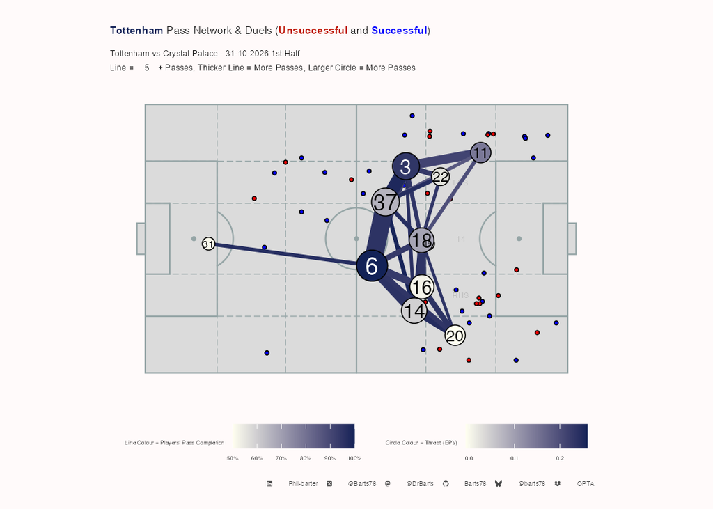

Away Pass Maps

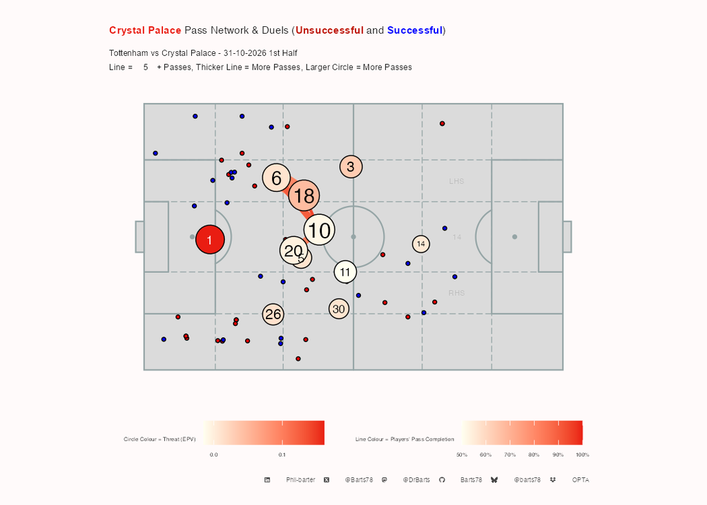

Home Pass Maps by Time

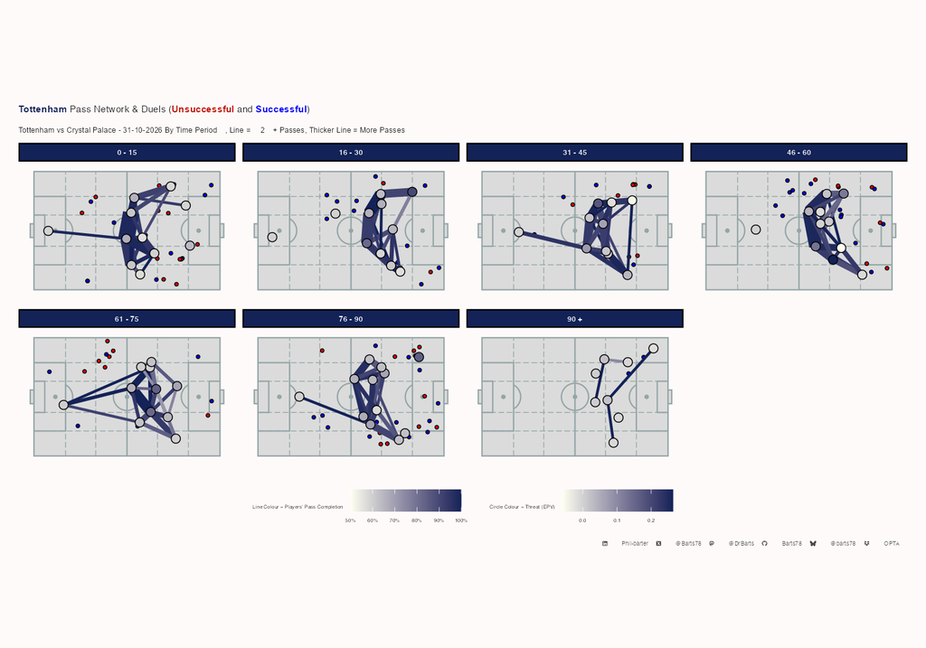

Away Pass Maps by Time

[figure not shown]

Home Attacking Pass Maps

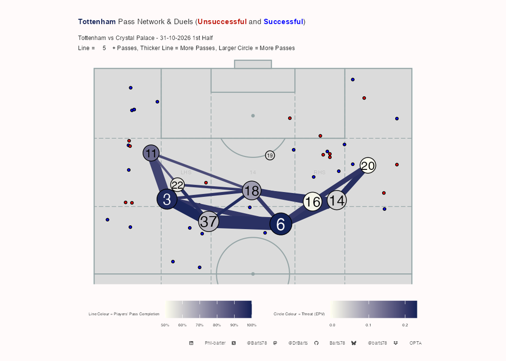

Away Attacking Pass Maps

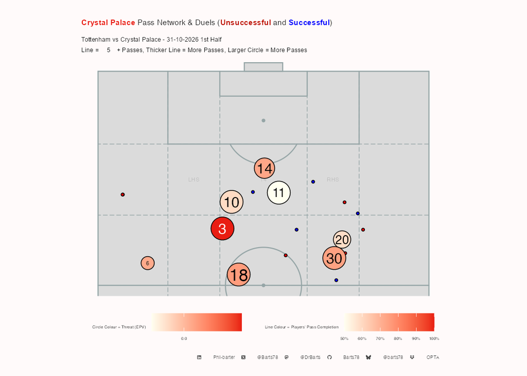

Home Attacking Pass Maps by Time

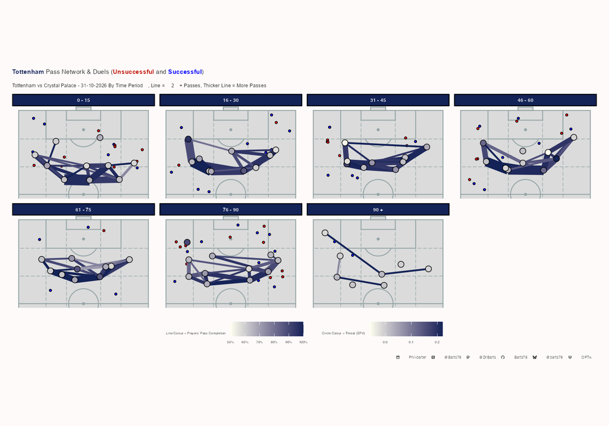

Away Attacking Pass Maps by Time

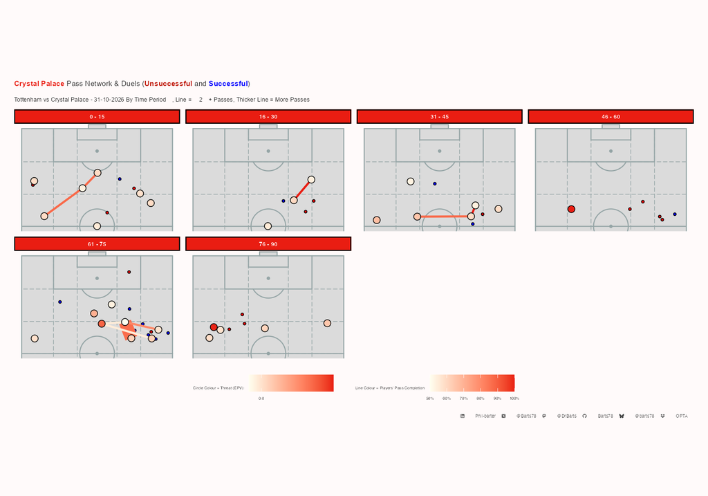

**Pass Connections by Passer**

Tottenham Open Play Passing connections

Tottenham vs Crystal Palace - 31-10-2026 | Completed passes only, min 5 per pair. Passer Completion % = all of the passer's attempts

|  | Completed Passes | % of Passer's Completions | % of Receiver's Receptions | Passer Completion % | Long Passes | Final Third Passes | PK Box Passes | Crosses | Key Passes | Prog Passes | EPV | EPV / Pass | Pass Time |
| --- | --- | --- | --- | --- | --- | --- | --- | --- | --- | --- | --- | --- | --- |
| Andy Robertson |  |  |  |  |  |  |  |  |  |  |  |  |  |
| Jan Paul van Hecke | 14 | 16% | 11% | 96% | 0 | 3 | 0 | 0 | 0 | 1 | 0.019 | 0.001 | 3.43 |
| Mateus Fernandes | 9 | 11% | 14% | 96% | 0 | 5 | 0 | 0 | 0 | 0 | 0.024 | 0.003 | 2.33 |
| Mathys Tel | 26 | 31% | 42% | 96% | 0 | 16 | 0 | 0 | 0 | 2 | 0.127 | 0.005 | 3.27 |
| Micky van de Ven | 20 | 24% | 20% | 96% | 0 | 13 | 0 | 0 | 0 | 1 | 0.059 | 0.003 | 2.85 |
| Omar Marmoush | 5 | 6% | 21% | 96% | 0 | 2 | 0 | 0 | 0 | 3 | 0.024 | 0.005 | 2.60 |
| Antonín Kinsky |  |  |  |  |  |  |  |  |  |  |  |  |  |
| Jan Paul van Hecke | 5 | 38% | 4% | 100% | 0 | 0 | 0 | 0 | 0 | 0 | 0.002 | 0.000 | 4.20 |
| Archie Gray |  |  |  |  |  |  |  |  |  |  |  |  |  |
| Jan Paul van Hecke | 19 | 41% | 15% | 98% | 0 | 6 | 0 | 0 | 0 | 1 | 0.043 | 0.002 | 2.79 |
| Mohammed Kudus | 14 | 30% | 20% | 98% | 0 | 6 | 1 | 0 | 1 | 2 | 0.076 | 0.005 | 1.86 |
| Sandro Tonali | 6 | 13% | 8% | 98% | 0 | 3 | 1 | 0 | 0 | 0 | 0.010 | 0.002 | 1.33 |
| Conor Gallagher |  |  |  |  |  |  |  |  |  |  |  |  |  |
| Destiny Udogie | 5 | 29% | 36% | 90% | 0 | 3 | 0 | 0 | 0 | 2 | 0.037 | 0.007 | 2.80 |
| Jan Paul van Hecke |  |  |  |  |  |  |  |  |  |  |  |  |  |
| Andy Robertson | 13 | 9% | 15% | 95% | 0 | 3 | 0 | 0 | 1 | 0 | 0.040 | 0.003 | 2.54 |
| Archie Gray | 11 | 8% | 27% | 95% | 0 | 3 | 0 | 0 | 0 | 0 | 0.016 | 0.001 | 3.00 |
| Mateus Fernandes | 14 | 10% | 23% | 95% | 0 | 1 | 0 | 0 | 0 | 5 | 0.041 | 0.003 | 2.57 |
| Micky van de Ven | 42 | 29% | 41% | 95% | 0 | 5 | 0 | 0 | 0 | 5 | 0.054 | 0.001 | 3.12 |
| Mohammed Kudus | 12 | 8% | 17% | 95% | 0 | 6 | 0 | 0 | 0 | 1 | 0.070 | 0.006 | 2.83 |
| Omar Marmoush | 5 | 4% | 21% | 95% | 0 | 3 | 0 | 0 | 1 | 4 | 0.048 | 0.010 | 2.40 |
| Pedro Porro | 16 | 11% | 36% | 95% | 0 | 7 | 0 | 0 | 1 | 1 | 0.126 | 0.008 | 2.69 |
| Sandro Tonali | 17 | 12% | 24% | 95% | 0 | 5 | 0 | 0 | 0 | 3 | 0.065 | 0.004 | 1.88 |
| Mateus Fernandes |  |  |  |  |  |  |  |  |  |  |  |  |  |
| Andy Robertson | 5 | 7% | 6% | 89% | 0 | 1 | 1 | 0 | 0 | 0 | 0.021 | 0.004 | 2.40 |
| Archie Gray | 5 | 7% | 12% | 89% | 0 | 4 | 0 | 0 | 0 | 0 | 0.029 | 0.006 | 2.00 |
| Jan Paul van Hecke | 7 | 10% | 6% | 89% | 0 | 4 | 0 | 0 | 0 | 1 | 0.017 | 0.002 | 3.71 |
| Mathys Tel | 9 | 12% | 14% | 89% | 1 | 6 | 0 | 0 | 0 | 3 | 0.106 | 0.012 | 3.44 |
| Micky van de Ven | 8 | 11% | 8% | 89% | 0 | 4 | 0 | 0 | 0 | 0 | 0.032 | 0.004 | 4.38 |
| Mohammed Kudus | 5 | 7% | 7% | 89% | 0 | 4 | 0 | 0 | 0 | 0 | 0.012 | 0.002 | 1.60 |
| Pedro Porro | 6 | 8% | 13% | 89% | 0 | 1 | 0 | 0 | 1 | 0 | 0.022 | 0.004 | 2.67 |
| Sandro Tonali | 17 | 24% | 24% | 89% | 0 | 6 | 0 | 0 | 0 | 0 | 0.038 | 0.002 | 2.06 |
| Mathys Tel |  |  |  |  |  |  |  |  |  |  |  |  |  |
| Andy Robertson | 15 | 34% | 17% | 83% | 0 | 13 | 0 | 0 | 0 | 1 | 0.098 | 0.007 | 2.13 |
| Mateus Fernandes | 6 | 14% | 10% | 83% | 0 | 6 | 0 | 0 | 0 | 3 | 0.054 | 0.009 | 2.17 |
| Micky van de Ven | 8 | 18% | 8% | 83% | 0 | 3 | 0 | 0 | 0 | 0 | 0.027 | 0.003 | 2.12 |
| Micky van de Ven |  |  |  |  |  |  |  |  |  |  |  |  |  |
| Andy Robertson | 37 | 30% | 42% | 100% | 0 | 10 | 0 | 0 | 0 | 0 | 0.098 | 0.003 | 2.41 |
| Destiny Udogie | 7 | 6% | 50% | 100% | 0 | 0 | 0 | 0 | 0 | 0 | 0.017 | 0.002 | 3.57 |
| Jan Paul van Hecke | 40 | 32% | 32% | 100% | 0 | 12 | 0 | 0 | 1 | 5 | 0.071 | 0.002 | 3.10 |
| Mathys Tel | 10 | 8% | 16% | 100% | 0 | 1 | 0 | 0 | 2 | 2 | 0.035 | 0.003 | 2.90 |
| Omar Marmoush | 5 | 4% | 21% | 100% | 0 | 2 | 0 | 0 | 0 | 1 | 0.012 | 0.002 | 1.20 |
| Mohammed Kudus |  |  |  |  |  |  |  |  |  |  |  |  |  |
| Archie Gray | 7 | 14% | 17% | 91% | 0 | 6 | 1 | 0 | 0 | 0 | 0.054 | 0.008 | 2.86 |
| Jan Paul van Hecke | 13 | 26% | 10% | 91% | 0 | 11 | 0 | 0 | 0 | 1 | 0.062 | 0.005 | 2.92 |
| Pedro Porro | 6 | 12% | 13% | 91% | 0 | 4 | 0 | 0 | 0 | 0 | 0.023 | 0.004 | 2.50 |
| Sandro Tonali | 14 | 28% | 20% | 91% | 0 | 12 | 0 | 0 | 0 | 2 | 0.080 | 0.006 | 2.21 |
| Omar Marmoush |  |  |  |  |  |  |  |  |  |  |  |  |  |
| Andy Robertson | 10 | 42% | 11% | 92% | 0 | 5 | 1 | 0 | 1 | 0 | 0.047 | 0.005 | 2.00 |
| Pedro Porro |  |  |  |  |  |  |  |  |  |  |  |  |  |
| Jan Paul van Hecke | 10 | 22% | 8% | 90% | 0 | 7 | 0 | 0 | 0 | 1 | 0.032 | 0.003 | 2.50 |
| Mateus Fernandes | 6 | 13% | 10% | 90% | 0 | 3 | 0 | 0 | 0 | 0 | 0.013 | 0.002 | 2.33 |
| Mohammed Kudus | 16 | 36% | 23% | 90% | 1 | 10 | 0 | 0 | 0 | 3 | 0.135 | 0.008 | 2.06 |
| Sandro Tonali |  |  |  |  |  |  |  |  |  |  |  |  |  |
| Archie Gray | 10 | 14% | 24% | 93% | 0 | 4 | 0 | 0 | 0 | 0 | 0.023 | 0.002 | 2.60 |
| Jan Paul van Hecke | 11 | 16% | 9% | 93% | 0 | 8 | 0 | 0 | 0 | 0 | 0.053 | 0.005 | 2.91 |
| Mateus Fernandes | 11 | 16% | 18% | 93% | 0 | 7 | 1 | 0 | 0 | 0 | 0.037 | 0.003 | 1.36 |
| Micky van de Ven | 5 | 7% | 5% | 93% | 0 | 2 | 0 | 0 | 0 | 0 | 0.027 | 0.005 | 1.80 |
| Mohammed Kudus | 18 | 26% | 26% | 93% | 0 | 13 | 1 | 0 | 0 | 0 | 0.084 | 0.005 | 2.33 |
| Pedro Porro | 6 | 9% | 13% | 93% | 0 | 1 | 0 | 0 | 0 | 0 | 0.016 | 0.003 | 2.67 |

X @Barts78 · Bluesky @barts78 · Mastodon @DrBarts · GitHub Barts78 · LinkedIn Phil-barter · Data: Opta

**Pass Connections by Receiver**

Tottenham Open Play Passing connections

Tottenham vs Crystal Palace - 31-10-2026 | Completed passes only, min 5 per pair. Passer Completion % = all of the passer's attempts

|  | Completed Passes | % of Passer's Completions | % of Receiver's Receptions | Passer Completion % | Long Passes | Final Third Passes | PK Box Passes | Crosses | Key Passes | Prog Passes | EPV | EPV / Pass | Pass Time |
| --- | --- | --- | --- | --- | --- | --- | --- | --- | --- | --- | --- | --- | --- |
| Jan Paul van Hecke |  |  |  |  |  |  |  |  |  |  |  |  |  |
| Andy Robertson | 14 | 16% | 11% | 96% | 0 | 3 | 0 | 0 | 0 | 1 | 0.019 | 0.001 | 3.43 |
| Antonín Kinsky | 5 | 38% | 4% | 100% | 0 | 0 | 0 | 0 | 0 | 0 | 0.002 | 0.000 | 4.20 |
| Archie Gray | 19 | 41% | 15% | 98% | 0 | 6 | 0 | 0 | 0 | 1 | 0.043 | 0.002 | 2.79 |
| Mateus Fernandes | 7 | 10% | 6% | 89% | 0 | 4 | 0 | 0 | 0 | 1 | 0.017 | 0.002 | 3.71 |
| Micky van de Ven | 40 | 32% | 32% | 100% | 0 | 12 | 0 | 0 | 1 | 5 | 0.071 | 0.002 | 3.10 |
| Mohammed Kudus | 13 | 26% | 10% | 91% | 0 | 11 | 0 | 0 | 0 | 1 | 0.062 | 0.005 | 2.92 |
| Pedro Porro | 10 | 22% | 8% | 90% | 0 | 7 | 0 | 0 | 0 | 1 | 0.032 | 0.003 | 2.50 |
| Sandro Tonali | 11 | 16% | 9% | 93% | 0 | 8 | 0 | 0 | 0 | 0 | 0.053 | 0.005 | 2.91 |
| Mateus Fernandes |  |  |  |  |  |  |  |  |  |  |  |  |  |
| Andy Robertson | 9 | 11% | 14% | 96% | 0 | 5 | 0 | 0 | 0 | 0 | 0.024 | 0.003 | 2.33 |
| Jan Paul van Hecke | 14 | 10% | 23% | 95% | 0 | 1 | 0 | 0 | 0 | 5 | 0.041 | 0.003 | 2.57 |
| Mathys Tel | 6 | 14% | 10% | 83% | 0 | 6 | 0 | 0 | 0 | 3 | 0.054 | 0.009 | 2.17 |
| Pedro Porro | 6 | 13% | 10% | 90% | 0 | 3 | 0 | 0 | 0 | 0 | 0.013 | 0.002 | 2.33 |
| Sandro Tonali | 11 | 16% | 18% | 93% | 0 | 7 | 1 | 0 | 0 | 0 | 0.037 | 0.003 | 1.36 |
| Mathys Tel |  |  |  |  |  |  |  |  |  |  |  |  |  |
| Andy Robertson | 26 | 31% | 42% | 96% | 0 | 16 | 0 | 0 | 0 | 2 | 0.127 | 0.005 | 3.27 |
| Mateus Fernandes | 9 | 12% | 14% | 89% | 1 | 6 | 0 | 0 | 0 | 3 | 0.106 | 0.012 | 3.44 |
| Micky van de Ven | 10 | 8% | 16% | 100% | 0 | 1 | 0 | 0 | 2 | 2 | 0.035 | 0.003 | 2.90 |
| Micky van de Ven |  |  |  |  |  |  |  |  |  |  |  |  |  |
| Andy Robertson | 20 | 24% | 20% | 96% | 0 | 13 | 0 | 0 | 0 | 1 | 0.059 | 0.003 | 2.85 |
| Jan Paul van Hecke | 42 | 29% | 41% | 95% | 0 | 5 | 0 | 0 | 0 | 5 | 0.054 | 0.001 | 3.12 |
| Mateus Fernandes | 8 | 11% | 8% | 89% | 0 | 4 | 0 | 0 | 0 | 0 | 0.032 | 0.004 | 4.38 |
| Mathys Tel | 8 | 18% | 8% | 83% | 0 | 3 | 0 | 0 | 0 | 0 | 0.027 | 0.003 | 2.12 |
| Sandro Tonali | 5 | 7% | 5% | 93% | 0 | 2 | 0 | 0 | 0 | 0 | 0.027 | 0.005 | 1.80 |
| Omar Marmoush |  |  |  |  |  |  |  |  |  |  |  |  |  |
| Andy Robertson | 5 | 6% | 21% | 96% | 0 | 2 | 0 | 0 | 0 | 3 | 0.024 | 0.005 | 2.60 |
| Jan Paul van Hecke | 5 | 4% | 21% | 95% | 0 | 3 | 0 | 0 | 1 | 4 | 0.048 | 0.010 | 2.40 |
| Micky van de Ven | 5 | 4% | 21% | 100% | 0 | 2 | 0 | 0 | 0 | 1 | 0.012 | 0.002 | 1.20 |
| Mohammed Kudus |  |  |  |  |  |  |  |  |  |  |  |  |  |
| Archie Gray | 14 | 30% | 20% | 98% | 0 | 6 | 1 | 0 | 1 | 2 | 0.076 | 0.005 | 1.86 |
| Jan Paul van Hecke | 12 | 8% | 17% | 95% | 0 | 6 | 0 | 0 | 0 | 1 | 0.070 | 0.006 | 2.83 |
| Mateus Fernandes | 5 | 7% | 7% | 89% | 0 | 4 | 0 | 0 | 0 | 0 | 0.012 | 0.002 | 1.60 |
| Pedro Porro | 16 | 36% | 23% | 90% | 1 | 10 | 0 | 0 | 0 | 3 | 0.135 | 0.008 | 2.06 |
| Sandro Tonali | 18 | 26% | 26% | 93% | 0 | 13 | 1 | 0 | 0 | 0 | 0.084 | 0.005 | 2.33 |
| Sandro Tonali |  |  |  |  |  |  |  |  |  |  |  |  |  |
| Archie Gray | 6 | 13% | 8% | 98% | 0 | 3 | 1 | 0 | 0 | 0 | 0.010 | 0.002 | 1.33 |
| Jan Paul van Hecke | 17 | 12% | 24% | 95% | 0 | 5 | 0 | 0 | 0 | 3 | 0.065 | 0.004 | 1.88 |
| Mateus Fernandes | 17 | 24% | 24% | 89% | 0 | 6 | 0 | 0 | 0 | 0 | 0.038 | 0.002 | 2.06 |
| Mohammed Kudus | 14 | 28% | 20% | 91% | 0 | 12 | 0 | 0 | 0 | 2 | 0.080 | 0.006 | 2.21 |
| Destiny Udogie |  |  |  |  |  |  |  |  |  |  |  |  |  |
| Conor Gallagher | 5 | 29% | 36% | 90% | 0 | 3 | 0 | 0 | 0 | 2 | 0.037 | 0.007 | 2.80 |
| Micky van de Ven | 7 | 6% | 50% | 100% | 0 | 0 | 0 | 0 | 0 | 0 | 0.017 | 0.002 | 3.57 |
| Andy Robertson |  |  |  |  |  |  |  |  |  |  |  |  |  |
| Jan Paul van Hecke | 13 | 9% | 15% | 95% | 0 | 3 | 0 | 0 | 1 | 0 | 0.040 | 0.003 | 2.54 |
| Mateus Fernandes | 5 | 7% | 6% | 89% | 0 | 1 | 1 | 0 | 0 | 0 | 0.021 | 0.004 | 2.40 |
| Mathys Tel | 15 | 34% | 17% | 83% | 0 | 13 | 0 | 0 | 0 | 1 | 0.098 | 0.007 | 2.13 |
| Micky van de Ven | 37 | 30% | 42% | 100% | 0 | 10 | 0 | 0 | 0 | 0 | 0.098 | 0.003 | 2.41 |
| Omar Marmoush | 10 | 42% | 11% | 92% | 0 | 5 | 1 | 0 | 1 | 0 | 0.047 | 0.005 | 2.00 |
| Archie Gray |  |  |  |  |  |  |  |  |  |  |  |  |  |
| Jan Paul van Hecke | 11 | 8% | 27% | 95% | 0 | 3 | 0 | 0 | 0 | 0 | 0.016 | 0.001 | 3.00 |
| Mateus Fernandes | 5 | 7% | 12% | 89% | 0 | 4 | 0 | 0 | 0 | 0 | 0.029 | 0.006 | 2.00 |
| Mohammed Kudus | 7 | 14% | 17% | 91% | 0 | 6 | 1 | 0 | 0 | 0 | 0.054 | 0.008 | 2.86 |
| Sandro Tonali | 10 | 14% | 24% | 93% | 0 | 4 | 0 | 0 | 0 | 0 | 0.023 | 0.002 | 2.60 |
| Pedro Porro |  |  |  |  |  |  |  |  |  |  |  |  |  |
| Jan Paul van Hecke | 16 | 11% | 36% | 95% | 0 | 7 | 0 | 0 | 1 | 1 | 0.126 | 0.008 | 2.69 |
| Mateus Fernandes | 6 | 8% | 13% | 89% | 0 | 1 | 0 | 0 | 1 | 0 | 0.022 | 0.004 | 2.67 |
| Mohammed Kudus | 6 | 12% | 13% | 91% | 0 | 4 | 0 | 0 | 0 | 0 | 0.023 | 0.004 | 2.50 |
| Sandro Tonali | 6 | 9% | 13% | 93% | 0 | 1 | 0 | 0 | 0 | 0 | 0.016 | 0.003 | 2.67 |

X @Barts78 · Bluesky @barts78 · Mastodon @DrBarts · GitHub Barts78 · LinkedIn Phil-barter · Data: Opta

**Away Pass Connections by Passer**

Crystal Palace Open Play Passing connections

Tottenham vs Crystal Palace - 31-10-2026 | Completed passes only, min 5 per pair. Passer Completion % = all of the passer's attempts

|  | Completed Passes | % of Passer's Completions | % of Receiver's Receptions | Passer Completion % | Long Passes | Final Third Passes | PK Box Passes | Crosses | Key Passes | Prog Passes | EPV | EPV / Pass | Pass Time |
| --- | --- | --- | --- | --- | --- | --- | --- | --- | --- | --- | --- | --- | --- |
| Daichi Kamada |  |  |  |  |  |  |  |  |  |  |  |  |  |
| Jaydee Canvot | 6 | 33% | 35% | 67% | 0 | 0 | 0 | 0 | 0 | 0 | 0.006 | 0.001 | 3.17 |
| Jaydee Canvot |  |  |  |  |  |  |  |  |  |  |  |  |  |
| Daichi Kamada | 5 | 28% | 24% | 86% | 0 | 1 | 0 | 0 | 0 | 1 | 0.031 | 0.006 | 2.20 |
| Tyrick Mitchell | 5 | 28% | 38% | 86% | 0 | 0 | 0 | 0 | 0 | 0 | 0.002 | 0.000 | 3.00 |
| Yéremy Pino |  |  |  |  |  |  |  |  |  |  |  |  |  |
| Daichi Kamada | 5 | 29% | 24% | 77% | 0 | 1 | 0 | 0 | 0 | 0 | 0.010 | 0.002 | 4.20 |

X @Barts78 · Bluesky @barts78 · Mastodon @DrBarts · GitHub Barts78 · LinkedIn Phil-barter · Data: Opta

**Away Pass Connections by Receiver**

Crystal Palace Open Play Passing connections

Tottenham vs Crystal Palace - 31-10-2026 | Completed passes only, min 5 per pair. Passer Completion % = all of the passer's attempts

|  | Completed Passes | % of Passer's Completions | % of Receiver's Receptions | Passer Completion % | Long Passes | Final Third Passes | PK Box Passes | Crosses | Key Passes | Prog Passes | EPV | EPV / Pass | Pass Time |
| --- | --- | --- | --- | --- | --- | --- | --- | --- | --- | --- | --- | --- | --- |
| Jaydee Canvot |  |  |  |  |  |  |  |  |  |  |  |  |  |
| Daichi Kamada | 6 | 33% | 35% | 67% | 0 | 0 | 0 | 0 | 0 | 0 | 0.006 | 0.001 | 3.17 |
| Daichi Kamada |  |  |  |  |  |  |  |  |  |  |  |  |  |
| Jaydee Canvot | 5 | 28% | 24% | 86% | 0 | 1 | 0 | 0 | 0 | 1 | 0.031 | 0.006 | 2.20 |
| Yéremy Pino | 5 | 29% | 24% | 77% | 0 | 1 | 0 | 0 | 0 | 0 | 0.010 | 0.002 | 4.20 |
| Tyrick Mitchell |  |  |  |  |  |  |  |  |  |  |  |  |  |
| Jaydee Canvot | 5 | 28% | 38% | 86% | 0 | 0 | 0 | 0 | 0 | 0 | 0.002 | 0.000 | 3.00 |

X @Barts78 · Bluesky @barts78 · Mastodon @DrBarts · GitHub Barts78 · LinkedIn Phil-barter · Data: Opta

Home Passing Tree Plot

[figure not shown]

Away Passing Tree Plot

[figure not shown]

Home wave plot

[figure not shown]

Away wave plot

[figure not shown]

**Home 1st Half Pass receiving Areas**

[figure not shown]

**Home 2nd Half Pass receiving Areas**

[figure not shown]

**Home Up to 1st Sub Pass receiving Areas**

[figure not shown]

**Away 1st Half Pass receiving Areas**

[figure not shown]

**Away 2nd Half Pass receiving Areas**

[figure not shown]

**Away Up to 1st Sub Pass receiving Areas**

[figure not shown]

Home Passing chains

[figure not shown]

Away Passing Chains

[figure not shown]

**Full time**

Tottenham FT Passing Chain Length (5, 6-10, 11-15, 16 +) & Distance (m)

Tottenham vs Crystal Palace - 31-10-2026

|  | Pass Chain Length | Total Chain Passes | Max Chain Length | Average Chain Length | Percent of Teams Passes | Total Chain Distance | Max Chain Distance | Average Chain Distance | Percent of Teams Passing Distance |
| --- | --- | --- | --- | --- | --- | --- | --- | --- | --- |
|  | VLow | 229 | 5 | 3 | 29% | 2,744.40 | 114.21 | 12.00 | 28% |
|  | Low | 210 | 10 | 8 | 26% | 2,653.30 | 155.48 | 12.60 | 27% |
|  | Medium | 144 | 15 | 13 | 18% | 1,955.11 | 224.83 | 13.60 | 20% |
|  | High | 210 | 23 | 19 | 26% | 2,500.84 | 263.58 | 11.90 | 25% |
| Overall Totals | — | 793 | 53 | 43 | — | 9,854 | 758 | 50 | — |
| Overall Average | — | 198 | 13 | 11 | — | 2,463 | 190 | 13 | — |

X @Barts78 · Bluesky @barts78 · Mastodon @DrBarts · GitHub Barts78 · LinkedIn Phil-barter · Data: Opta

**1st Half**

Tottenham 1st Half Passing Chain Length (5, 6-10, 11-15, 16 +) & Distance (m)

Tottenham vs Crystal Palace - 31-10-2026

|  | Pass Chain Length | Total Chain Passes | Max Chain Length | Average Chain Length | Percent of Teams Passes | Total Chain Distance | Max Chain Distance | Average Chain Distance | Percent of Teams Passing Distance |
| --- | --- | --- | --- | --- | --- | --- | --- | --- | --- |
|  | VLow | 100 | 5 | 3 | 25% | 1,061.73 | 110.21 | 10.60 | 22% |
|  | Low | 120 | 10 | 9 | 30% | 1,493.70 | 152.10 | 12.40 | 31% |
|  | Medium | 66 | 15 | 13 | 16% | 869.63 | 217.16 | 13.20 | 18% |
|  | High | 114 | 23 | 19 | 28% | 1,371.64 | 263.58 | 12.00 | 29% |
| Overall Totals | — | 400 | 53 | 44 | — | 4,797 | 743 | 48 | — |
| Overall Average | — | 100 | 13 | 11 | — | 1,199 | 186 | 12 | — |

X @Barts78 · Bluesky @barts78 · Mastodon @DrBarts · GitHub Barts78 · LinkedIn Phil-barter · Data: Opta

**2nd Half**

Tottenham 2nd Half Passing Chain Length (5, 6-10, 11-15, 16 +) & Distance (m)

Tottenham vs Crystal Palace - 31-10-2026

|  | Pass Chain Length | Total Chain Passes | Max Chain Length | Average Chain Length | Percent of Teams Passes | Total Chain Distance | Max Chain Distance | Average Chain Distance | Percent of Teams Passing Distance |
| --- | --- | --- | --- | --- | --- | --- | --- | --- | --- |
|  | VLow | 129 | 5 | 3 | 33% | 1,682.67 | 114.21 | 13.00 | 33% |
|  | Low | 90 | 9 | 8 | 23% | 1,159.60 | 155.48 | 12.90 | 23% |
|  | Medium | 78 | 14 | 13 | 20% | 1,085.48 | 224.83 | 13.90 | 21% |
|  | High | 96 | 21 | 19 | 24% | 1,129.20 | 255.47 | 11.80 | 22% |
| Overall Totals | — | 393 | 49 | 43 | — | 5,057 | 750 | 52 | — |
| Overall Average | — | 98 | 12 | 11 | — | 1,264 | 187 | 13 | — |

X @Barts78 · Bluesky @barts78 · Mastodon @DrBarts · GitHub Barts78 · LinkedIn Phil-barter · Data: Opta

**Away Full time**

Crystal Palace FT Passing Chain Length (5, 6-10, 11-15, 16 +) & Distance (m)

Tottenham vs Crystal Palace - 31-10-2026

|  | Pass Chain Length | Total Chain Passes | Max Chain Length | Average Chain Length | Percent of Teams Passes | Total Chain Distance | Max Chain Distance | Average Chain Distance | Percent of Teams Passing Distance |
| --- | --- | --- | --- | --- | --- | --- | --- | --- | --- |
|  | VLow | 109 | 5 | 2 | 69% | 1,669.32 | 88.10 | 15.30 | 72% |
|  | Low | 19 | 10 | 10 | 12% | 289.87 | 182.74 | 15.30 | 12% |
|  | Medium | 13 | 13 | 13 | 8% | 179.64 | 179.64 | 13.80 | 8% |
|  | High | 17 | 17 | 17 | 11% | 192.12 | 192.12 | 11.30 | 8% |
| Overall Totals | — | 158 | 45 | 42 | — | 2,331 | 643 | 56 | — |
| Overall Average | — | 40 | 11 | 10 | — | 583 | 161 | 14 | — |

X @Barts78 · Bluesky @barts78 · Mastodon @DrBarts · GitHub Barts78 · LinkedIn Phil-barter · Data: Opta

**Away 1st Half**

Crystal Palace 1st Half Passing Chain Length (5, 6-10, 11-15, 16 +) & Distance (m)

Tottenham vs Crystal Palace - 31-10-2026

|  | Pass Chain Length | Total Chain Passes | Max Chain Length | Average Chain Length | Percent of Teams Passes | Total Chain Distance | Max Chain Distance | Average Chain Distance | Percent of Teams Passing Distance |
| --- | --- | --- | --- | --- | --- | --- | --- | --- | --- |
|  | VLow | 57 | 5 | 3 | 59% | 866.25 | 81.43 | 15.20 | 61% |
|  | Low | 10 | 10 | 10 | 10% | 182.74 | 182.74 | 18.30 | 13% |
|  | Medium | 13 | 13 | 13 | 13% | 179.64 | 179.64 | 13.80 | 13% |
|  | High | 17 | 17 | 17 | 18% | 192.12 | 192.12 | 11.30 | 14% |
| Overall Totals | — | 97 | 45 | 43 | — | 1,421 | 636 | 59 | — |
| Overall Average | — | 24 | 11 | 11 | — | 355 | 159 | 15 | — |

X @Barts78 · Bluesky @barts78 · Mastodon @DrBarts · GitHub Barts78 · LinkedIn Phil-barter · Data: Opta

**Away 2nd Half**

Crystal Palace 2nd Half Passing Chain Length (5, 6-10, 11-15, 16 +) & Distance (m)

Tottenham vs Crystal Palace - 31-10-2026

|  | Pass Chain Length | Total Chain Passes | Max Chain Length | Average Chain Length | Percent of Teams Passes | Total Chain Distance | Max Chain Distance | Average Chain Distance | Percent of Teams Passing Distance |
| --- | --- | --- | --- | --- | --- | --- | --- | --- | --- |
|  | VLow | 52 | 5 | 2 | 85% | 803.07 | 88.10 | 15.40 | 88% |
|  | Low | 9 | 9 | 9 | 15% | 107.13 | 107.13 | 11.90 | 12% |
| Overall Totals | — | 61 | 14 | 11 | — | 910 | 195 | 27 | — |
| Overall Average | — | 30 | 7 | 6 | — | 455 | 98 | 14 | — |

X @Barts78 · Bluesky @barts78 · Mastodon @DrBarts · GitHub Barts78 · LinkedIn Phil-barter · Data: Opta

**Home Z14 RS By Half**

[figure not shown]

**Home Z14 RS By Game Period**

[figure not shown]

**Away Z14 RS By Half**

[figure not shown]

**Away Z14 RS By Game Period**

[figure not shown]

**Home Long Passes By half**

[figure not shown]

**Home Long Passes By Game Period**

[figure not shown]

**Away Long Passes By Half**

[figure not shown]

**Away Long Passes By Game period**

[figure not shown]

Set-Piece Summary

**Set Pieces**

Tottenham vs Crystal Palace - 31-10-2026

|  | Tottenham | Crystal Palace |
| --- | --- | --- |
| Corners |  |  |
| Corners taken | 19 | 0 |
| Short | 10 | 0 |
| Direct | 9 | 0 |
| Direct - first contact won | 3 (33%) | 0 (-) |
| Free kicks |  |  |
| Free kicks (passes) | 11 | 10 |
| Into final third / box | 4 | 4 |
| Into box | 3 | 0 |
| Throw-ins |  |  |
| Throw-ins | 21 | 10 |
| Retained (first touch) | 95% | 60% |
| Shots by situation |  |  |
| Open-play shots | 23 | 1 |
| Open-play xG | 1.93 | 0.04 |
| Open-play goals | 0 | 0 |
| Set-piece shots | 11 | 1 |
| Set-piece xG | 1.60 | 0.11 |
| Set-piece goals | 2 | 0 |
| Penalties | 0 | 0 |
| Penalty xG | 0.00 | 0.00 |
| Set-piece share of xG | 45% | 73% |

First contact: the team that touches the ball first after the delivery (aerial duels go to the winner). Throw-ins retained = first touch by the taking team.  
X @Barts78 · Bluesky @barts78 · Mastodon @DrBarts · GitHub Barts78 · LinkedIn Phil-barter · Data: Opta

**Corners**

[figure not shown]

**Free Kicks**

[figure not shown]

**Corners**

[figure not shown]

**Free Kicks**

[figure not shown]

**Sequence Map**

[figure not shown]

**Sequence Table**

**Tottenham - Shot-Creating Sequences**

Tottenham vs Crystal Palace - 31-10-2026

| Min | Shooter | Result | xG | Situation | Started by | Started from | Start zone | Passes | Duration (s) |
| --- | --- | --- | --- | --- | --- | --- | --- | --- | --- |
| 17' | Solanke | Blocked | 0.03 | Open play | Fernandes | Open-play regain | Mid third, Right half-space | 4 | 10 |
| 22' | Tel | Blocked | 0.04 | Open play | Kinsky | Free kick | Def third, Central | 20 | 65 |
| 23' | Kudus | Off target | 0.20 | Open play | Kinsky | Free kick | Def third, Central | 31 | 93 |
| 25' | Gray | Goal | 0.13 | Set piece | Kudus | Corner | Att third, Right wing | 1 | 2 |
| 27' | Solanke | Off target | 0.19 | Set piece | Robertson | Free kick | Att third, Left wing | 1 | 2 |
| 33' | Kudus | Off target | 0.01 | Set piece | Fernandes | Corner | Att third, Left wing | 2 | 3 |
| 40' | Robertson | Saved | 0.03 | Open play | Marmoush | Open-play regain | Mid third, Left half-space | 11 | 32 |
| 41' | Marmoush | Blocked | 0.03 | Open play | Tonali | Open-play regain | Mid third, Central | 11 | 38 |
| 46' | Tel | Blocked | 0.06 | Open play | Solanke | Open-play regain | Att third, Right half-space | 1 | 4 |
| 47' | Fernandes | Blocked | 0.02 | Set piece | Kudus | Corner | Att third, Right wing | 1 | 4 |
| 47' | van Hecke | Off target | 0.23 | Set piece | Kudus | Corner | Att third, Right wing | 2 | 3 |
| 49' | Fernandes | Off target | 0.02 | Open play | Fernandes | Open-play regain | Att third, Right half-space | 0 | 1 |
| 50' | Marmoush | Saved | 0.06 | Open play | Robertson | Throw-in | Mid third, Left wing | 7 | 21 |
| 51' | Solanke | Saved | 0.09 | Open play | Kinsky | Open-play regain | Def third, Central | 9 | 27 |
| 52' | Porro | Blocked | 0.02 | Open play | Marmoush | Open-play regain | Att third, Left half-space | 1 | 6 |
| 55' | Fernandes | Blocked | 0.04 | Open play | van Hecke | Open-play regain | Att third, Right half-space | 2 | 10 |
| 57' | van Hecke | Off target | 0.16 | Set piece | van Hecke | Open-play regain | Att third, Central | 0 | 0 |
| 58' | Marmoush | Blocked | 0.02 | Open play | van de Ven | Open-play regain | Att third, Central | 4 | 11 |
| 59' | Solanke | Blocked | 0.06 | Open play | Fernandes | Open-play regain | Mid third, Central | 3 | 5 |
| 61' | van Hecke | Off target | 0.02 | Open play | Kinsky | Keeper | Def third, Central | 17 | 40 |
| 65' | Porro | Off target | 0.05 | Open play | van Hecke | Throw-in | Mid third, Right wing | 20 | 69 |
| 67' | Tel | Off target | 0.03 | Open play | van de Ven | Open-play regain | Mid third, Central | 1 | 3 |
| 68' | Marmoush | Blocked | 0.03 | Open play | Tonali | Throw-in | Att third, Right wing | 9 | 23 |
| 70' | Tel | Blocked | 0.13 | Open play | Kudus | Open-play regain | Def third, Right half-space | 2 | 16 |
| 71' | Robertson | Saved | 0.08 | Open play | Gallagher | Open-play regain | Att third, Left half-space | 22 | 54 |
| 73' | Gallagher | Blocked | 0.05 | Set piece | Fernandes | Corner | Att third, Left wing | 1 | 5 |
| 73' | van Hecke | Saved | 0.18 | Set piece | Fernandes | Corner | Att third, Left wing | 3 | 13 |
| 73' | van Hecke | Goal | 0.43 | Set piece | van Hecke | Open-play regain | Att third, Central | 0 | 0 |
| 76' | Tonali | Off target | 0.03 | Open play | Tonali | Open-play regain | Att third, Right half-space | 0 | 2 |
| 81' | Gallagher | Saved | 0.28 | Open play | Udogie | Open-play regain | Mid third, Left wing | 10 | 30 |
| 82' | Gallagher | Blocked | 0.15 | Set piece | Kudus | Corner | Att third, Right wing | 1 | 3 |
| 88' | Porro | Off target | 0.05 | Set piece | Fernandes | Corner | Att third, Left wing | 2 | 4 |
| 90' | Kudus | Off target | 0.55 | Open play | Tonali | Throw-in | Mid third, Right wing | 5 | 21 |
| 90+1' | Kulusevski | Saved | 0.03 | Open play | Tonali | Open-play regain | Mid third, Central | 2 | 6 |

X @Barts78 · Bluesky @barts78 · Mastodon @DrBarts · GitHub Barts78 · LinkedIn Phil-barter · Data: Opta

**Sequence Map**

[figure not shown]

**Sequence Table**

**Crystal Palace - Shot-Creating Sequences**

Tottenham vs Crystal Palace - 31-10-2026

| Min | Shooter | Result | xG | Situation | Started by | Started from | Start zone | Passes | Duration (s) |
| --- | --- | --- | --- | --- | --- | --- | --- | --- | --- |
| 9' | Kamada | Saved | 0.04 | Open play | Mingueza | Open-play regain | Mid third, Right wing | 3 | 6 |
| 63' | McNeil | Blocked | 0.11 | Set piece | Richards | Throw-in | Att third, Right wing | 4 | 15 |

X @Barts78 · Bluesky @barts78 · Mastodon @DrBarts · GitHub Barts78 · LinkedIn Phil-barter · Data: Opta

Entries by Channel

**Box and Final-Third Entries (open play)**

Tottenham vs Crystal Palace - 31-10-2026

|  | Box entries Passes | Box entries Carries | Box entries Total | Box entries Success % | Final-third entries Passes | Final-third entries Carries | Final-third entries Total | Final-third entries Success % |
| --- | --- | --- | --- | --- | --- | --- | --- | --- |
| Tottenham |  |  |  |  |  |  |  |  |
| Left wing | 16 | 5 | 21 | 52% | 6 | 3 | 9 | 89% |
| Left half-space | 7 | 2 | 9 | 56% | 14 | 2 | 16 | 81% |
| Central | 6 | 1 | 7 | 57% | 50 | 7 | 57 | 96% |
| Right half-space | 4 | 2 | 6 | 67% | 18 | 3 | 21 | 86% |
| Right wing | 15 | 2 | 17 | 35% | 13 | 2 | 15 | 93% |
| Total | 48 | 12 | 60 | 50% | 101 | 17 | 118 | 92% |
| Crystal Palace |  |  |  |  |  |  |  |  |
| Left wing | 1 | 0 | 1 | 0% | 2 | 0 | 2 | 0% |
| Left half-space | 2 | 0 | 2 | 50% | 4 | 0 | 4 | 75% |
| Central | 1 | 0 | 1 | 100% | 6 | 1 | 7 | 57% |
| Right half-space | 0 | 0 | 0 | - | 4 | 0 | 4 | 50% |
| Right wing | 1 | 0 | 1 | 0% | 3 | 1 | 4 | 25% |
| Total | 5 | 0 | 5 | 40% | 19 | 2 | 21 | 48% |

Channel = where the pass or carry started. Left/right from the attacking team's view. Set pieces excluded.  
X @Barts78 · Bluesky @barts78 · Mastodon @DrBarts · GitHub Barts78 · LinkedIn Phil-barter · Data: Opta

**Box**

[figure not shown]

**Final Third**

[figure not shown]

**Box**

[figure not shown]

**Final Third**

[figure not shown]

**Match Stats**

**Passing stats**

Tottenham vs Crystal Palace - 31-10-2026

|  | Name | Mins | % of Team Possession | xA | xT | Attempted Passes | Successful Passes | Pass Success % | Assists | BCs | Key Passes | Long Ps | Final 3rd P | Prog Ps | PK Box P | Pass Received | PPs Received | KPs Recieved | Recieveing Suc | EPV Recieved | EPV Created | % of Team EPV |
| --- | --- | --- | --- | --- | --- | --- | --- | --- | --- | --- | --- | --- | --- | --- | --- | --- | --- | --- | --- | --- | --- | --- |
| Keeper | Antonín Kinsky | 95 | 0.02 | 0 | 0 | 13 | 13 | 1 | 0 | 0 | 0 | 0 | 0 | 0 | 0 | 14 | 0 | 0 | 0.714285714285714 | 0.33 | 0.017 | 0 |
| Defender | Jan Paul van Hecke | 95 | 0.15 | 0 | 0.23 | 151 | 143 | 0.95 | 0 | 2 | 3 | 1 | 38 | 19 | 0 | 140 | 10 | 1 | 0.907142857142857 | 0.457 | 0.508 | 0.1 |
| Defender | Micky van de Ven | 95 | 0.12 | 0 | 0.14 | 123 | 123 | 1 | 0 | 0 | 3 | 0 | 31 | 9 | 0 | 119 | 6 | 0 | 0.857142857142857 | 0.413 | 0.302 | 0.06 |
| Defender | Andy Robertson | 79 | 0.1 | 0.15 | 0.99 | 89 | 85 | 0.96 | 0 | 1 | 3 | 1 | 43 | 10 | 0 | 91 | 1 | 2 | 0.978021978021978 | 0.336 | 1.097 | 0.21 |
| Defender | Archie Gray | 48 | 0.06 | 0.22 | 0.16 | 47 | 46 | 0.98 | 0 | 1 | 1 | 1 | 19 | 4 | 2 | 45 | 0 | 0 | 0.933333333333333 | 0.157 | 0.138 | 0.03 |
| Defender | Pedro Porro | 47 | 0.05 | 0.09 | 0.34 | 50 | 45 | 0.9 | 0 | 0 | 1 | 5 | 27 | 7 | 1 | 48 | 2 | 3 | 0.9375 | 0.27 | 0.351 | 0.07 |
| Defender | Destiny Udogie | 16 | 0.02 | 0 | 0.04 | 15 | 13 | 0.87 | 0 | 0 | 0 | 0 | 3 | 0 | 0 | 17 | 2 | 0 | 0.823529411764706 | 0.067 | 0.051 | 0.01 |
| Midfielder | Mateus Fernandes | 95 | 0.1 | 0 | 0.73 | 81 | 72 | 0.89 | 0 | 0 | 4 | 2 | 42 | 8 | 2 | 72 | 9 | 0 | 0.861111111111111 | 0.248 | 0.73 | 0.14 |
| Midfielder | Mohammed Kudus | 95 | 0.09 | 0.45 | 0.73 | 55 | 50 | 0.91 | 1 | 1 | 3 | 0 | 47 | 6 | 2 | 69 | 7 | 2 | 1 | 0.573 | 0.829 | 0.16 |
| Midfielder | Sandro Tonali | 95 | 0.09 | 0 | 0.17 | 74 | 69 | 0.93 | 0 | 0 | 0 | 2 | 44 | 1 | 3 | 74 | 9 | 0 | 0.959459459459459 | 0.315 | 0.299 | 0.06 |

[output cut: 6 more lines]

X @Barts78 · Bluesky @barts78 · Mastodon @DrBarts · GitHub Barts78 · LinkedIn Phil-barter · Data: Opta

**Touches and Carries**

Tottenham vs Crystal Palace - 31-10-2026

|  | Name | Mins | Touches | Def 3rd | Mid 3rd | Final 3rd | PK Box | Total / Min | Def 3rd % TT | Mid Third % TT | Final 3rd % TT | PK Box % TT | Carries | % Carries Prog | % Carries F 3rd | % Carries D Prog | Total Dribbles | Dribbles Won | Dribbles Lost | Dribble Success |
| --- | --- | --- | --- | --- | --- | --- | --- | --- | --- | --- | --- | --- | --- | --- | --- | --- | --- | --- | --- | --- |
| Keeper | Antonín Kinsky | 95 | 18 | 16 | 2 | 0 | 0 | 0.189473684210526 | 0.888888888888889 | 0.111111111111111 | 0 | 0 | 10 | 0 | 0 | 0 | 0 | 0 | 0 | 0 |
| Defender | Jan Paul van Hecke | 95 | 160 | 16 | 100 | 44 | 5 | 1.68421052631579 | 0.1 | 0.625 | 0.275 | 0.03125 | 21 | 0.0476190476190476 | 0.142857142857143 | 0.0294155816066099 | 0 | 0 | 0 | 0 |
| Defender | Micky van de Ven | 95 | 132 | 17 | 83 | 32 | 0 | 1.38947368421053 | 0.128787878787879 | 0.628787878787879 | 0.242424242424242 | 0 | 35 | 0.114285714285714 | 0.342857142857143 | 0.138418238108641 | 0 | 0 | 0 | 0 |
| Defender | Andy Robertson | 79 | 109 | 9 | 42 | 58 | 3 | 1.37974683544304 | 0.0825688073394495 | 0.385321100917431 | 0.532110091743119 | 0.0275229357798165 | 22 | 0.0909090909090909 | 0.5 | 0.0720366466677477 | 0 | 0 | 0 | 0 |
| Defender | Archie Gray | 48 | 61 | 4 | 29 | 28 | 5 | 1.27083333333333 | 0.0655737704918033 | 0.475409836065574 | 0.459016393442623 | 0.0819672131147541 | 6 | 0 | 0.833333333333333 | 0 | 0 | 0 | 0 | 0 |
| Defender | Pedro Porro | 47 | 58 | 7 | 16 | 35 | 4 | 1.23404255319149 | 0.120689655172414 | 0.275862068965517 | 0.603448275862069 | 0.0689655172413793 | 10 | 0 | 0.7 | 0 | 0 | 0 | 0 | 0 |
| Defender | Destiny Udogie | 16 | 24 | 1 | 13 | 10 | 0 | 1.5 | 0.0416666666666667 | 0.541666666666667 | 0.416666666666667 | 0 | 7 | 0 | 0.428571428571429 | 0 | 1 | 0 | 1 | 0 |
| Midfielder | Mateus Fernandes | 95 | 107 | 6 | 41 | 60 | 4 | 1.12631578947368 | 0.0560747663551402 | 0.383177570093458 | 0.560747663551402 | 0.0373831775700935 | 16 | 0.0625 | 0.4375 | 0.0717606943583385 | 0 | 0 | 0 | 0 |
| Midfielder | Mohammed Kudus | 95 | 99 | 3 | 11 | 85 | 11 | 1.04210526315789 | 0.0303030303030303 | 0.111111111111111 | 0.858585858585859 | 0.111111111111111 | 13 | 0 | 0.692307692307692 | 0 | 12 | 4 | 8 | 0.333333333333333 |
| Midfielder | Sandro Tonali | 95 | 93 | 2 | 34 | 57 | 5 | 0.978947368421053 | 0.021505376344086 | 0.365591397849462 | 0.612903225806452 | 0.0537634408602151 | 16 | 0.0625 | 0.375 | 0.075539369861502 | 0 | 0 | 0 | 0 |

[output cut: 6 more lines]

X @Barts78 · Bluesky @barts78 · Mastodon @DrBarts · GitHub Barts78 · LinkedIn Phil-barter · Data: Opta

**Shooting stats**

Tottenham vs Crystal Palace - 31-10-2026